# Weight Lifting Exercise Analysis

## Executive Summary

Using devices such as Jawbone Up, Nike FuelBand, and Fitbit it is now possible to collect a large amount of data about personal activity relatively inexpensively. These type of devices are part of the quantified self movement - a group of enthusiasts who take measurements about themselves regularly to improve their health, to find patterns in their behavior, or because they are tech geeks.

One thing that people regularly do is quantify how much of a particular activity they do, but they rarely quantify how well they do it.

The goal of this project is to use data from accelerometers on the belt, forearm, arm, and dumbell of 6 participants. They were asked to perform barbell lifts correctly and incorrectly in 5 different ways.

More information is available from the website here: http://groupware.les.inf.puc-rio.br/har (see the section on the Weight Lifting Exercise Dataset).

The goal of this project is to predict the “classe” variable in the training set.

## Data Processing

The training data for this project are available here:

https://d396qusza40orc.cloudfront.net/predmachlearn/pml-training.csv

The test data are available here:

https://d396qusza40orc.cloudfront.net/predmachlearn/pml-testing.csv

Loading the required libraries and reading in the training and testing datasets.

```r
library(caret)
input <- read.csv("pml-training.csv", header = TRUE, na.strings = c('', 'NA'))
input_test <- read.csv("pml-testing.csv", header = TRUE, na.strings = c('', 'NA'))
```

The original datasets contain columns without data. Applying appropriate logical variable I filtered out those columns that are missing values.

```r
train_less_columns <- input[, column_sums_log]
```

Creating logical vector in order to delete unnecessary columns from the cleaned training and testing datasets.

```r
delete_columns <- grepl("X|timestamp|new_window|user_name",
                      colnames(train_less_columns))
input_test_final <- input_test[, !delete_columns]
train_less_columns <- train_less_columns[, !delete_columns]
```

I have splitted the updated training dataset into a smaller training dataset (70% of the observations from the original training set) and a smaller validation dataset (30% of the observations from the original training set).

This validation dataset will be used to perform cross validation and to be able to test the model accuracy.

```r
inTrain = createDataPartition(y = train_less_columns$classe, p = 0.7, list = FALSE)
small_train_set = train_less_columns[inTrain, ]
small_validation = train_less_columns[-inTrain, ]
```

## Machine Learning

The training dataset (small_train_set) contains 54 variables, and the last column is the ‘classe’ variable , which the machine learning model will be predicting.

After pre-processing, the function ‘predict’ is used for pre-processing of both the training and validation subsets.

```r
valid_test.pca <- predict(preProc, small_validation[, -54])
```

The machine learning model is trained using a random forest method on the smaller training dataset. Applying the random forest routine, in the ‘trainControl()’ parameter the use of a cross validation method is specified.

The relative importance of the resulting principal components of the trained model, ‘fit’ can be reviewed now.

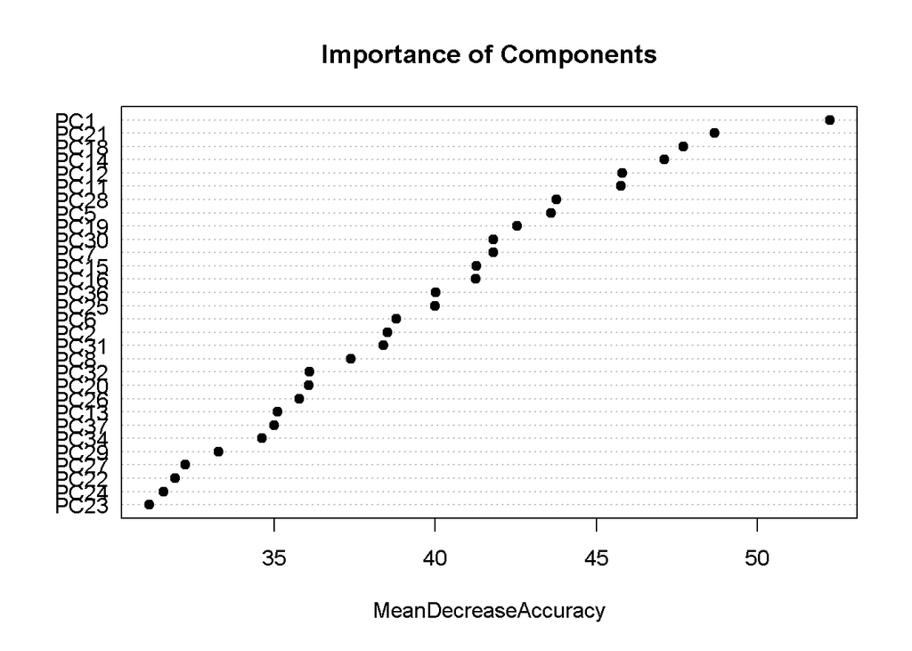

```r
varImpPlot(fit$finalModel, sort = TRUE, pch = 19, type = 1, col = 1, cex = 1,
           main = "Importance of Components")
```

## Cross Validation Testing

The ‘predict’ function is used so that the model can be applied to the cross validation testing dataset.

The resulting table of the output of ‘confusionMatrix’ function indicates how the model predicted/classified the values in the validation test set

```r
confus <- confusionMatrix(small_validation$classe, predict_validation_rf)
confus$table
```

```
##           Reference
## Prediction    A    B    C    D    E
##          A 1671    1    1    1    0
##          B   21 1106   12    0    0
##          C    1   13 1005    7    0
##          D    0    0   37  923    4
##          E    0    1    2    5 1074
```

The estimated out-of-sample error and the model’s accuracy, can be estimated using the ‘postresample’ function.

```r
model_acc
```

```
## [1] 0.982
```

```r
out_of_sample_error <- 1 - model_acc
out_of_sample_error
```

```
## [1] 0.01801
```

The estimated accuracy of the model is 98.2% and the estimated out-of-sample error based on fitted model and the cross validation dataset is 1.8%.

## Predicted Results

```r
predict_final <- predict(fit, test.pca)
#predict_final
```